# Exploratory data analysis

EDA represents various fixture-level college basketball (NCAA Basketball / which is added to the database (mydatabase.db)) statistics from the past 2 years. The objective is to build a model that is able to predict the winners for the upcoming fixtures. The Raw data contains > FixtureKey,Team,X2PM,X2PA,X3PM,X3PA,FTM,FTA,ORB,DRB,AST,STL,BLK,TOV,PF

The EDA itself is an exploratory section in the project, hence the simplistic regression model is adopted in the process. Not much effort is taken into evaluate the model or calibrate the model as the focus of the assessment is something else. The winner prediction model here extremely confident in its predictions, this can be due to overfitting or certain features heavily influencing the model’s decision boundary. One of the main reason is the base score calcutaion itself is based on the variables that have low confidence.

## Data preparation

Please refer to section 2.a, titled ‘Data preprocessing,’ in the README.MD for the code related to transferring data into the database

## Data Preprocessing

Please refer to section 2.b in the README.MD for the code where extensive data cleaning is performed using SQL queries instead of Python. In Python, we solely rely on SQL queries to retrieve the already cleaned data.

### Libraries/Main Query

Performing extensive data cleaning within SQL queries focuses on data preprocessing. Specifically, it addresses the task of making the initial calculations to obtain the necessary variables to cacluate the base score of each team within the fixture.

```r
library(tidymodels)
library(skimr)
library(rsample)
library(purrr)
library(recipes)
library(caret)
library(ggplot2)
library(pROC)
library(RSQLite)
library(DT)
library(flexdashboard)
con <- dbConnect(RSQLite::SQLite(), "mydatabase.db")

#================================query================================================

qurt1 <-
"WITH TeamAvTeamB AS (
    SELECT
        bs.FixtureKey,
        SUBSTR(bs.FixtureKey, 1, LENGTH(bs.FixtureKey) - 12) AS TeamAvTeamB
    FROM
        box_scores AS bs
)

-- Query 1 as a CTE
, Query1 AS (
    SELECT DISTINCT
        TRIM(CASE
                WHEN bs.Team = 1 THEN SUBSTR(TeamAvTeamB, 1, INSTR(TeamAvTeamB, 'v') - 1)
                WHEN bs.Team = 2 THEN SUBSTR(TeamAvTeamB, INSTR(TeamAvTeamB, 'v') + 1)
                ELSE NULL
            END) AS TeamName,
        AVG(bs.ORB) AS ORBAvg,
        AVG(bs.DRB) AS DRBAvg,
        AVG(bs.STL) AS STLAvg,
        AVG(bs.BLK) AS BLKAvg,
        AVG(bs.PF) AS PFAvg

    FROM
        TeamAvTeamB AS ta
    JOIN box_scores AS bs ON ta.FixtureKey = bs.FixtureKey
    GROUP BY
        TeamName
)

-- Query 2 as a CTE
, Query2 AS (
    SELECT
        bs.FixtureKey,
        TRIM(CASE
                WHEN bs.Team = 1 THEN SUBSTR(TeamAvTeamB, 1, INSTR(TeamAvTeamB, 'v') - 1)
                WHEN bs.Team = 2 THEN SUBSTR(TeamAvTeamB, INSTR(TeamAvTeamB, 'v') + 1)
                ELSE NULL
            END) AS TeamName,
        TRIM(CASE
                WHEN bs.Team = 2 THEN SUBSTR(TeamAvTeamB, 1, INSTR(TeamAvTeamB, 'v') - 1)
                WHEN bs.Team = 1 THEN SUBSTR(TeamAvTeamB, INSTR(TeamAvTeamB, 'v') + 1)
                ELSE NULL
            END) AS Oppnent,
            CASE
              WHEN bs.Team = 1 THEN 'Yes'
              WHEN bs.TeaM = 2 THEN 'No'
              ELSE NULL
              END AS HomeTeamAdv,
        bs.Team, bs.X2PM, bs.X2PA, bs.X3PM, bs.X3PA, bs.FTM, bs.FTA, bs.ORB, bs.DRB, bs.AST, bs.STL, bs.BLK, bs.TOV,
        bs.PF,
        ROUND((CAST(bs.X2PM AS REAL) + CAST(bs.X3PM AS REAL)) / (CAST(bs.X2PA AS REAL) + CAST(bs.X3PA AS REAL))*100,2) AS 'FG%',
        ROUND((CAST(bs.X2PM AS REAL) / CAST(bs.X3PA AS REAL))*100,2)  AS '3P%',
        ROUND((CAST(bs.FTM AS REAL) / CAST(bs.FTA AS REAL))*100,2)  AS 'FT%',
        ROUND((CAST(bs.AST AS REAL) / CAST(bs.TOV AS REAL))*100,2)  AS 'ASTtoTOV%'
    FROM
        TeamAvTeamB AS ta
    JOIN box_scores AS bs ON ta.FixtureKey = bs.FixtureKey
)

-- CTE3  Query joining Query1 and Query2 using TeamName
, FinalCTE AS (SELECT DISTINCT
    Query2.FixtureKey, Query2.TeamName,Query2.Oppnent, Query2.HomeTeamAdv, Query2.Team,Query2.X2PM, Query2.X2PA, Query2.X3PM, Query2.X3PA,Query2.FTM, Query2.FTA,
    Query2.ORB,Query2.DRB,Query2.AST,Query2.STL,Query2.BLK,Query2.TOV, Query2.PF,Query2.'FG%', Query2.'3P%',Query2.'FT%',Query2.'ASTtoTOV%',
    ROUND(Query1.ORBAvg, 2) AS ORBAvg,
    ROUND(Query3.ORBAvg, 2 ) AS OppORBAvg,
    ROUND(Query1.DRBAvg, 2) AS DRBAvg,
    ROUND(Query3.DRBAvg, 2) AS OppDRBAvg,
    ROUND(Query1.STLAvg, 2) AS STLAvg,
    ROUND(Query1.BLKAvg, 2) AS BLKAvg,
    ROUND(Query1.PFAvg, 2) AS PFAvg,
    ROUND(Query3.PFAvg, 2) AS OppPFAvg

FROM
    Query1
JOIN Query2 ON Query1.TeamName = Query2.TeamName
JOIN Query1 AS Query3 ON Query2.Oppnent = Query3.TeamName

)

--Joining Final CTE from BOX score table with fixture_information

 SELECT FinalCTE.FixtureKey, FinalCTE.TeamName ,FinalCTE.Oppnent, FinalCTE.'FG%',FinalCTE.'3P%',
 FinalCTE.'FT%', FinalCTE.'ASTtoTOV%',
 (FinalCTE.ORBAvg-FinalCTE.OppORBAvg) AS ORD,
 (FinalCTE.DRBAvg-FinalCTE.OppDRBAvg) AS DRD,
 FinalCTE.STLAvg ,FinalCTE.BLKAvg,
 (FinalCTE.PFAvg-FinalCTE.OppPFAvg) AS DiffPFAvg,
 FinalCTE.HomeTeamAdv,
 fixture_information.TipOff AS TipOff,
 fixture_information.GameType AS GameType,
 fixture_information.IsNeutralSite AS IsNeutralSite,
 fixture_information.Attendance AS Attendance,
 fixture_information.Season AS Season,
 fixture_information.Team1Conference AS Team1Conference,
 fixture_information.Team2Conference AS Team2Conference
 FROM
     FinalCTE
 JOIN fixture_information ON FinalCTE.FixtureKey = fixture_information.FixtureKey
"
#==========================================================query END======================

dfBoxScoresFromQuery <- dbGetQuery(con, qurt1)

datatable(head(dfBoxScoresFromQuery, 100),
          options = list(scrollX = TRUE))
```

|  | FixtureKey | TeamName | Oppnent | FG% | 3P% | FT% | ASTtoTOV% | ORD | DRD | STLAvg | BLKAvg | DiffPFAvg | HomeTeamAdv | TipOff | GameType | IsNeutralSite | Attendance | Season | Team1Conference | Team2Conference |
| --- | --- | --- | --- | --- | --- | --- | --- | --- | --- | --- | --- | --- | --- | --- | --- | --- | --- | --- | --- | --- |
| 1 | LIPSCO v A PEAY 14-Jan-2023 | A PEAY | LIPSCO | 40.32 | 85.71 | 93.75 | 108.33 | 2.380000000000001 | -5.550000000000001 | 6.11 | 2.6 | 4.130000000000001 | No | 17:00 | RegularSeason | 0 | 0 | 2023 | A-Sun | A-Sun |
| 2 | LIPSCO v A PEAY 14-Jan-2023 | LIPSCO | A PEAY | 50.98 | 72.73 | 82.76 | 130.77 | -2.380000000000001 | 5.550000000000001 | 4.82 | 2.47 | -4.130000000000001 | Yes | 17:00 | RegularSeason | 0 | 0 | 2023 | A-Sun | A-Sun |
| 3 | QUENNC v A PEAY 29-Dec-2022 | A PEAY | QUENNC | 45.16 | 111.11 | 86.67 | 180 | -0.009999999999999787 | -2.710000000000001 | 6.11 | 2.6 | 0.1400000000000006 | No | 18:00 | RegularSeason | 0 | 552 | 2023 | A-Sun | A-Sun |
| 4 | QUENNC v A PEAY 29-Dec-2022 | QUENNC | A PEAY | 49.02 | 94.74 | 66.67 | 107.69 | 0.009999999999999787 | 2.710000000000001 | 5.65 | 2.45 | -0.1400000000000006 | Yes | 18:00 | RegularSeason | 0 | 552 | 2023 | A-Sun | A-Sun |
| 5 | FGCU v A PEAY 24-Feb-2023 | A PEAY | FGCU | 45.16 | 60.61 | 63.64 | 190 | 0.6400000000000006 | -3.740000000000002 | 6.11 | 2.6 | 2.140000000000001 | No | 19:00 | RegularSeason | 0 | 2291 | 2023 | A-Sun | A-Sun |
| 6 | FGCU v A PEAY 24-Feb-2023 | FGCU | A PEAY | 51.72 | 65.38 | 80 | 166.67 | -0.6400000000000006 | 3.740000000000002 | 6.15 | 4.2 | -2.140000000000001 | Yes | 19:00 | RegularSeason | 0 | 2291 | 2023 | A-Sun | A-Sun |
| 7 | A PEAY v NO FLA 18-Feb-2023 | A PEAY | NO FLA | 47.62 | 133.33 | 58.33 | 171.43 | 1.210000000000001 | -2.060000000000002 | 6.11 | 2.6 | 2.380000000000001 | Yes | 16:00 | RegularSeason | 0 | 1975 | 2023 | A-Sun | A-Sun |
| 8 | A PEAY v NO FLA 18-Feb-2023 | NO FLA | A PEAY | 47.17 | 41.38 | 88.89 | 54.55 | -1.210000000000001 | 2.060000000000002 | 4.98 | 4 | -2.380000000000001 | No | 16:00 | RegularSeason | 0 | 1975 | 2023 | A-Sun | A-Sun |
| 9 | A PEAY v JVILLE 16-Feb-2023 | A PEAY | JVILLE | 34.69 | 21.43 | 84.62 | 78.57 | 1.32 | -3.380000000000003 | 6.11 | 2.6 | 1.970000000000001 | Yes | 20:00 | RegularSeason | 0 | 1497 | 2023 | A-Sun | A-Sun |
| 10 | A PEAY v JVILLE 16-Feb-2023 | JVILLE | A PEAY | 40 | 57.89 | 78.57 | 130 | -1.32 | 3.380000000000003 | 5.33 | 2.03 | -1.970000000000001 | No | 20:00 | RegularSeason | 0 | 1497 | 2023 | A-Sun | A-Sun |

[output cut: 90 more lines]

### Data Preprocessing (dplyr)

Further the table is cleaned using dplyr. Task of splitting the columns in the data obtained from the initial data preparation is done here, which are initially in the format TeamA_v_TeamB Date’ into separate team names. This separation allows for more efficient and structured analysis of each team’s aggregate statistics

```r
fiter_box_scoreFun <- function(df){
  df%>%rowwise()%>%
    mutate(Date = strsplit(FixtureKey, " ")[[1]]
           [length(strsplit(FixtureKey, " ")[[1]])])%>%
    mutate(Day = weekdays(as.Date(Date, format="%d-%b-%Y")))%>%
    mutate(
      HomeTeamAdv =
        if(HomeTeamAdv =="Yes" & IsNeutralSite == 0){
          "Yes"
        } else if (HomeTeamAdv =="No" & IsNeutralSite == 1) {
          "No"
        } else if (HomeTeamAdv =="Yes" & IsNeutralSite == 1) {
          "No"
        } else if (HomeTeamAdv =="No" & IsNeutralSite == 0) {
          "No"
        }
    )%>%
    #adding home advantage factor
    mutate(HomeTeamAdv = ifelse(HomeTeamAdv == "Yes", 1, 0) * 0.05)%>%
    #calculating base score
    mutate(Base_score = ((`FG%`*0.3) + (`3P%`*0.2)+(`FT%`*0.1)+(`ASTtoTOV%`*0.2)+
                           (ORD*0.05)+(DRD*0.05)+(STLAvg*0.03)+(BLKAvg*0.02)+(DiffPFAvg*0.03)+HomeTeamAdv))%>%
    #adding attendance factor
    mutate(Base_score = Base_score*ifelse(Attendance == 0, 1, 1+0.05*(Attendance/max(Attendance))))%>%
    #adding home GameType factor
    mutate(Base_score = case_when(
      GameType == "RegularSeason" ~ 1.0*Base_score,
      GameType == "ConferenceChampionship" ~ 1.1*Base_score,
      GameType == "NIT" ~ 1.2*Base_score,
      TRUE ~ 1.0*Base_score))%>%
    mutate(time_multiplier = as.integer(strsplit(TipOff[1],":")[[1]][1]))%>%
    mutate(Base_score = case_when(
      time_multiplier >= 6 & time_multiplier < 12 ~ 0.98*Base_score,
      time_multiplier >= 12 & time_multiplier < 17 ~ 1*Base_score,
      time_multiplier >= 17 & time_multiplier < 21 ~ 1.02*Base_score,
      TRUE ~ 1.01*Base_score
    ))%>%mutate(Base_score = case_when(
      Day == "Monday"~ 1.0*Base_score,
      Day == "Tuesday"~ 1.0*Base_score,
      Day == "Wednesday"~ 1.0*Base_score,
      Day == "Thursday"~ 1.0*Base_score,
      Day == "Friday"~ 1.01*Base_score,
      Day == "Saturday"~ 1.02*Base_score,
      Day == "Sunday"~ 1.01*Base_score
    ))%>%select(FixtureKey, TeamName,Oppnent,Base_score)
}


dfBoxScores <- fiter_box_scoreFun(dfBoxScoresFromQuery)

dfBoxScoresHome<- dfBoxScoresFromQuery%>%filter(HomeTeamAdv == "Yes")
dfBoxScoresHome <- fiter_box_scoreFun(dfBoxScoresHome)

dfBoxScoresAway<- dfBoxScoresFromQuery%>%filter(HomeTeamAdv == "No")
dfBoxScoresAway <- fiter_box_scoreFun(dfBoxScoresAway)


Final_Score <- merge(dfBoxScoresHome%>%rename(Home = TeamName, Away=Oppnent, Home_score = Base_score),
                     dfBoxScoresAway%>%rename(Away = TeamName, Home=Oppnent, Away_score = Base_score))%>%
  mutate(Home_score = round(Home_score,2),
         Away_score = round(Away_score,2))


dfboxscoresMean <- rbind(dfBoxScoresHome%>%select(-Oppnent, -FixtureKey),dfBoxScoresAway%>%select(-Oppnent, -FixtureKey ))%>%
  group_by(TeamName)%>%summarise(Base_score = mean(Base_score))

dfboxscoreMeadian <- rbind(dfBoxScoresHome%>%select(-Oppnent, -FixtureKey),dfBoxScoresAway%>%select(-Oppnent, -FixtureKey ))%>%
  group_by(TeamName)%>%summarise(Base_score = median(Base_score))


datatable(Final_Score)
```

|  | FixtureKey | Home | Away | Home_score | Away_score |
| --- | --- | --- | --- | --- | --- |
| 1 | A PEAY v BELMNT 27-Jan-2022 | A PEAY | BELMNT | 50.97 | 64.19 |
| 2 | A PEAY v C ARK 07-Jan-2023 | A PEAY | C ARK | 78.5 | 63.88 |
| 3 | A PEAY v E ILL 14-Feb-2022 | A PEAY | E ILL | 53.67 | 60.41 |
| 4 | A PEAY v E KY 21-Jan-2023 | A PEAY | E KY | 57.31 | 95.34 |
| 5 | A PEAY v HOWARD 26-Nov-2022 | A PEAY | HOWARD | 62.86 | 60.27 |
| 6 | A PEAY v JVILLE 16-Feb-2023 | A PEAY | JVILLE | 41.89 | 61.77 |
| 7 | A PEAY v MOREST 08-Jan-2022 | A PEAY | MOREST | 57.4 | 73.72 |
| 8 | A PEAY v NO FLA 18-Feb-2023 | A PEAY | NO FLA | 87.16 | 45.44 |
| 9 | A PEAY v SIUE 31-Jan-2022 | A PEAY | SIUE | 58.81 | 67.49 |
| 10 | A PEAY v TENNST 03-Dec-2022 | A PEAY | TENNST | 67.31 | 81.95 |

[output cut: 6651 more lines]

## Winner Prediction model

A separate winner prediction model is created here.

```r
#==============winner Prediction model ====================================================================

data <- Final_Score %>%select(!FixtureKey)%>%
  mutate(Winner = if_else(Home_score > Away_score, 1, 0))

dataSplit <- initial_split(data)
dataTrain <- training(dataSplit)
dataTest <- testing(dataSplit)


#hot coding using recipe library

training_recipe <- recipe(Winner ~ ., data=dataTrain) %>%
  step_dummy(Home, Away) %>%
  prep()


encoded_training_data <- bake(training_recipe, dataTrain)
#Regression prediction model

winner_prediction_model <- glm(Winner ~ ., family=binomial, data=encoded_training_data)
```

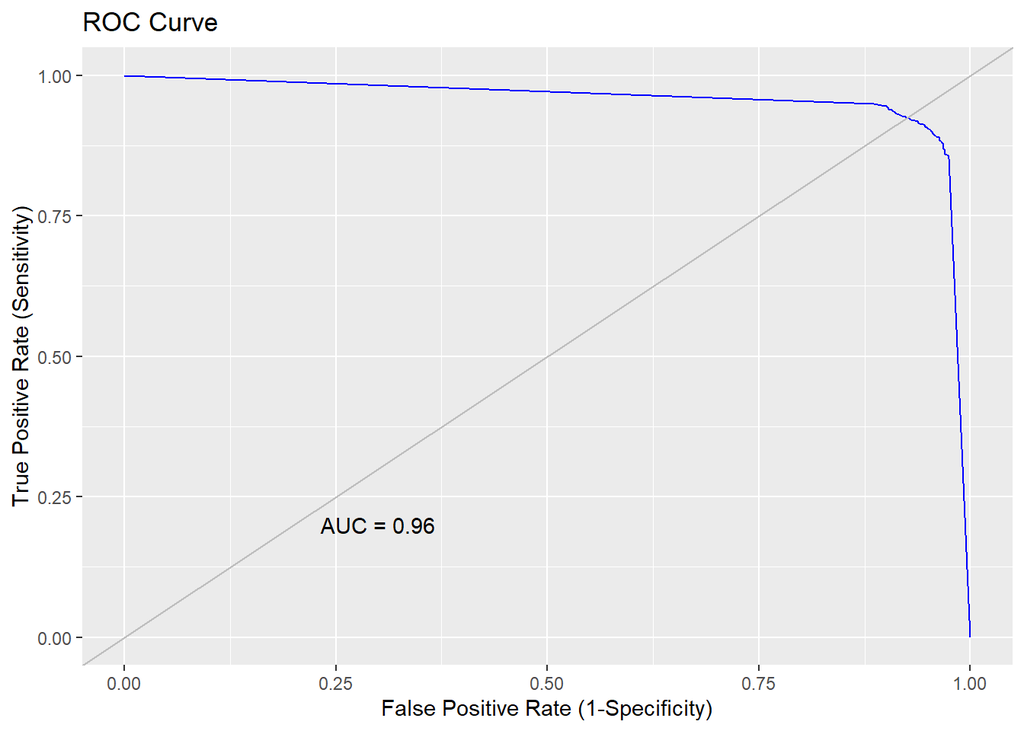

```r
#check for the NA values / residuals tune the model

encoded_test_data <- bake(training_recipe, dataTest)

winner_predictions <- predict(winner_prediction_model, newdata=encoded_test_data, type="response")

#plot & evaluate the model

observed_values <- dataTest$Winner

winner_predictions <- winner_predictions[!is.na(winner_predictions)]
observed_values <- observed_values[!is.na(observed_values)]

rmse_winner <- sqrt(mean((winner_predictions - observed_values)^2))

#plot
roc_obj <- roc(observed_values, winner_predictions)

winner_prediction_plot <- ggplot(data = data.frame(
  FPR = roc_obj$specificities,
  TPR = roc_obj$sensitivities
)) +
  geom_line(aes(x = FPR, y = TPR), color="blue") +
  geom_abline(intercept = 0, slope = 1, color="gray") +
  ggtitle("ROC Curve") +
  labs(x="False Positive Rate (1-Specificity)", y="True Positive Rate (Sensitivity)") +
  annotate("text", x = 0.3, y = 0.2, label = paste("AUC =", round(auc(roc_obj), 2)))

winner_prediction_plot
```

## Score Prediction Model

The models seems reasonably accurate for scores in the middle range but struggles more with extreme scores, both high and low. There’s a tendency for the models to under predict especially high scores and possibly to over predict especially low scores. This is obvious as the model is lacking evaluation and the feature engineering.

### Home(regression Plot)

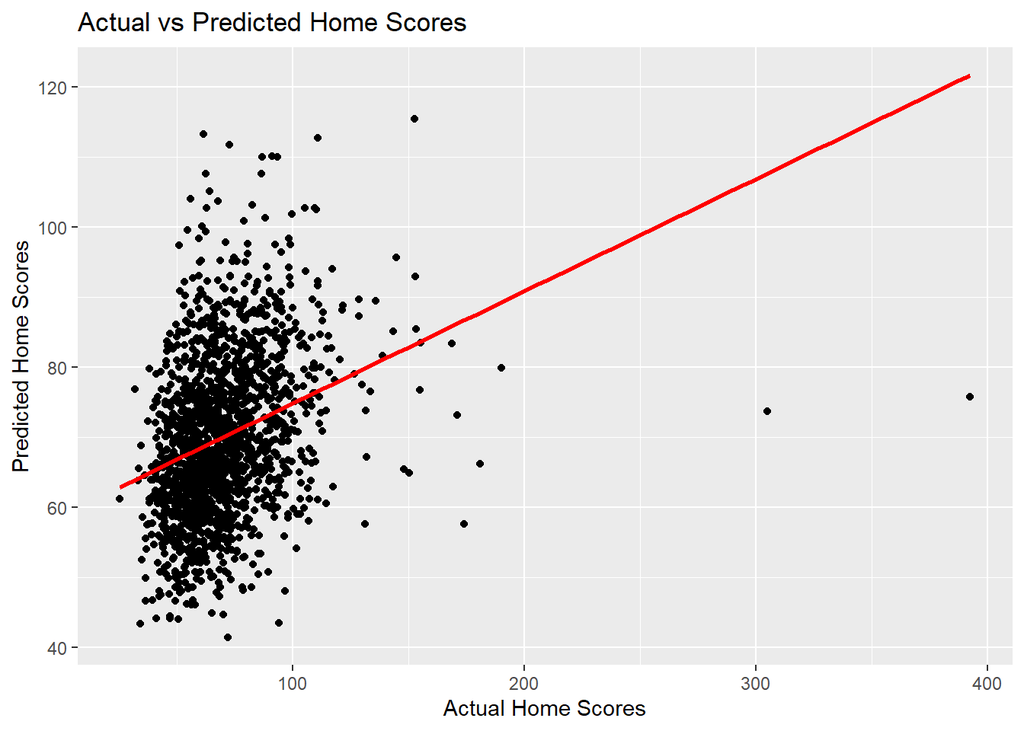

```r
Final_ScoreAvgScores <-  merge(Final_Score, dfboxscoresMean, by.x = "Home", by.y = "TeamName", all.x = TRUE)%>%rename(HomeScoreAvg = Base_score)%>%select(-FixtureKey)
Final_ScoreAvgScores <- merge(Final_ScoreAvgScores, dfboxscoresMean, by.x = "Away", by.y = "TeamName", all.x = TRUE)%>%rename(AwayScoreAvg = Base_score)

Final_ScoreAvgScores <- Final_ScoreAvgScores%>%select(Home, Away, HomeScoreAvg, AwayScoreAvg, Home_score, Away_score)



#home prediction

Home_recipe <- recipe(Home_score ~ Home + Away + HomeScoreAvg + AwayScoreAvg, data=Final_ScoreAvgScores) %>%
  step_dummy(Home, Away, one_hot=TRUE) %>%
  step_normalize(HomeScoreAvg, AwayScoreAvg) %>%
  prep()

processed_Home_data  <- juice(Home_recipe)

dataSplitHome <- initial_split(processed_Home_data)
dataTrainHome <- training(dataSplitHome)
dataTestHome <- testing(dataSplitHome)


model_home <- lm(Home_score ~ ., data=dataTrainHome)

predicted_home_scores_test <- predict(model_home, newdata=dataTestHome)

#plotting the graph / Evaluate the models
comparison_data_home <- data.frame(Actual = dataTestHome$Home_score, Predicted = predicted_home_scores_test)

homeScore_predictionModel <- ggplot(comparison_data_home, aes(x = Actual, y = Predicted)) +
  geom_point() +
  geom_smooth(method = "lm", se = FALSE, color = "red") +
  ggtitle("Actual vs Predicted Home Scores") +
  xlab("Actual Home Scores") +
  ylab("Predicted Home Scores")


homeScore_predictionModel
```

### Away(regression Plot)

```r
Away_recipe <- recipe(Away_score ~ Home + Away + HomeScoreAvg + AwayScoreAvg, data=Final_ScoreAvgScores) %>%
  step_dummy(Home, Away) %>%
  step_normalize(HomeScoreAvg, AwayScoreAvg) %>%
  prep()


processed_Away_data <- juice(Away_recipe)


dataSplitAway <- initial_split(processed_Away_data)
dataTrainAway <- training(dataSplitAway)
dataTestAway <- testing(dataSplitAway)

model_away <- lm(Away_score ~ ., data=dataTrainAway)

predicted_away_scores_test <- predict(model_away, newdata =dataTestAway )
```

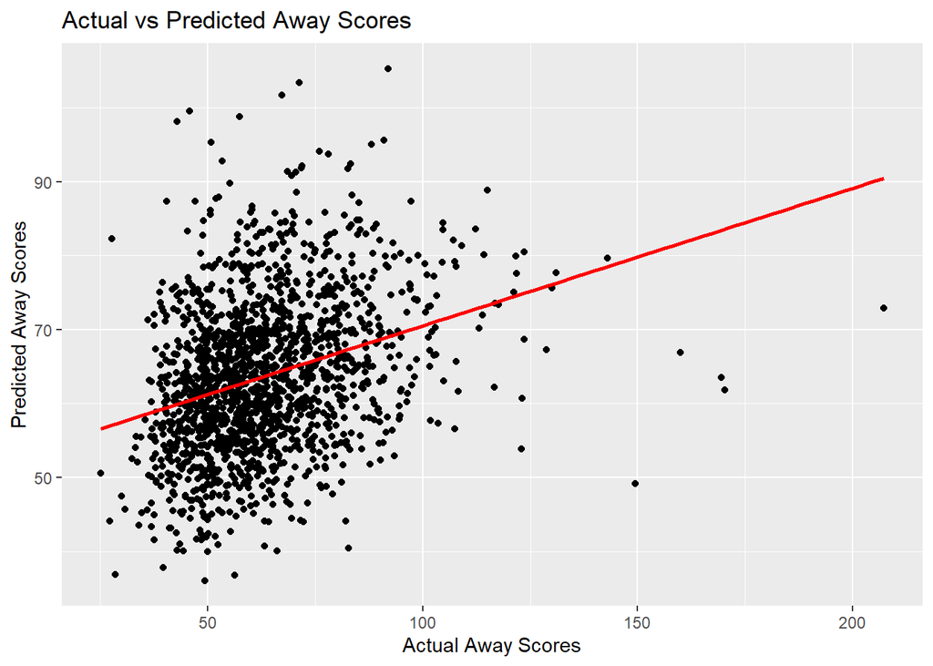

```r
#plot / evaluate the model

comparison_data_away <- data.frame(Actual = dataTestAway$Away_score, Predicted = predicted_away_scores_test)

awayScore_predictionModel <- ggplot(comparison_data_away, aes(x=Actual, y= Predicted))+
  geom_point()+
  geom_smooth(method = "lm", se = FALSE, color = "red")+
  ggtitle("Actual vs Predicted Away Scores") +
  xlab("Actual Away Scores") +
  ylab("Predicted Away Scores")

awayScore_predictionModel
```

## Upcoming Fixtures

```r
con <- dbConnect(RSQLite::SQLite(), "mydatabase.db")
df_test_fixtures <- dbGetQuery(con, "SELECT * FROM test_fixtures")
dbDisconnect(con)

df_test_fixtures <- df_test_fixtures%>%rowwise()%>%
  mutate(
    SplittedString = strsplit(FixtureKey, " "),
    TeamAvTeamB = paste(unlist(SplittedString[-length(SplittedString)]), collapse = " ")
  )%>%
  mutate(Home = strsplit(TeamAvTeamB, "(?<!V)v", perl = TRUE)[[1]][1],
         Away = strsplit(TeamAvTeamB, "(?<!V)v", perl = TRUE)[[1]][2],
         Home =  trimws(Home),
         Away = trimws(Away),
         Date = strsplit(FixtureKey, " ")[[1]]
         [length(strsplit(FixtureKey, " ")[[1]])]
  )%>%
  select(Date, Home, Away)

upcoming_match <- df_test_fixtures%>%select(!Date)


upcoming_match <-  merge(upcoming_match, dfboxscoresMean, by.x = "Home", by.y = "TeamName", all.x = TRUE)%>%rename(HomeScoreAvg = Base_score)
upcoming_match <- merge(upcoming_match, dfboxscoresMean, by.x = "Away", by.y = "TeamName", all.x = TRUE)%>%rename(AwayScoreAvg = Base_score)

datatable(upcoming_match%>%mutate(HomeScoreAvg= round(HomeScoreAvg,2),
                                   AwayScoreAvg= round(AwayScoreAvg, 2)))
```

|  | Away | Home | HomeScoreAvg | AwayScoreAvg |
| --- | --- | --- | --- | --- |
| 1 | AL A&amp;M | ALA ST | 59.01 | 63.44 |
| 2 | AMER | LOY MD | 66.81 | 77.41 |
| 3 | ARK | ALA | 64.59 | 78.97 |
| 4 | ARK PB | MS VAL | 58.82 | 54.58 |
| 5 | ARMY | HOLYCR | 65.38 | 63.52 |
| 6 | AUBURN | UK | 85.32 | 71.96 |
| 7 | AZ ST | ARIZ | 82.48 | 67.21 |
| 8 | BALLST | E MICH | 61.92 | 63.22 |
| 9 | BOISE | SJSU | 61.26 | 61.84 |
| 10 | BROWN | COLUMB | 54.13 | 59.63 |

[output cut: 120 more lines]

### Score Prediction

Predicting home and away scores for the upcoming fixtures

```r
processed_upcoming_fixture_home <- bake(Home_recipe, new_data = upcoming_match)
predicted_home_scores <- predict(model_home, newdata=processed_upcoming_fixture_home)


processed_upcoming_fixture_away <- bake(Away_recipe, new_data = upcoming_match)


#(predvars, data, env) : object 'Home_ABILCH' not found, adding a  column filled with zero
missing_cols <- setdiff(names(processed_Away_data), names(processed_upcoming_fixture_away))
for(col in missing_cols) {
  processed_upcoming_fixture_away[[col]] <- 0
}

predicted_away_scores <- predict(model_away, newdata=processed_upcoming_fixture_away)
upcoming_match_with_scores  <- cbind(upcoming_match, predicted_home_scores, predicted_away_scores)%>%
  select(!c(HomeScoreAvg,AwayScoreAvg))%>%
  mutate(across(everything(), ~replace_na(.x, 0)))%>%
  rename(Home_score = predicted_home_scores, Away_score = predicted_away_scores)

datatable(upcoming_match_with_scores%>%mutate(Home_score= round(Home_score,2),
                                   Away_score= round(Away_score, 2)))
```

|  | Away | Home | Home_score | Away_score |
| --- | --- | --- | --- | --- |
| 1 | AL A&amp;M | ALA ST | 50.58 | 53.17 |
| 2 | AMER | LOY MD | 69.98 | 75.23 |
| 3 | ARK | ALA | 56.62 | 64.97 |
| 4 | ARK PB | MS VAL | 70.26 | 81.89 |
| 5 | ARMY | HOLYCR | 57.02 | 85.52 |
| 6 | AUBURN | UK | 76.53 | 73.42 |
| 7 | AZ ST | ARIZ | 76.87 | 64.3 |
| 8 | BALLST | E MICH | 58.4 | 54.29 |
| 9 | BOISE | SJSU | 51.29 | 74.06 |
| 10 | BROWN | COLUMB | 55.28 | 72.67 |

[output cut: 120 more lines]

## Win%, Totals, Spread

Upcoming fixture with win%, Spread and Totals

```r
# Function to interpolate Win% for a given spread
interpolate_win_percentage <- function(spread_val, win_per_table) {
  # If spread greater than 19, return NA
  if (spread_val > 19) {
    return(NA_real_)
  }

  lower_row <- win_per_table %>% filter(spread <= spread_val) %>% arrange(desc(spread)) %>% slice(1)
  upper_row <- win_per_table %>% filter(spread > spread_val) %>% arrange(spread) %>% slice(1)

  if (nrow(lower_row) == 0) {
    return(upper_row$win_percentage)
  }
  if (nrow(upper_row) == 0) {
    return(lower_row$win_percentage)
  }

  x1 <- lower_row$spread
  y1 <- lower_row$win_percentage
  x2 <- upper_row$spread
  y2 <- upper_row$win_percentage

  # Interpolation formula
  y = y1 + ((spread_val - x1) * (y2 - y1)) / (x2 - x1)

  return(y)
}

# Mutate upcoming_fix with the interpolated Win%
upcoming_fix <- upcoming_fixture_predictions %>%
  rowwise() %>%
  mutate(WinPercentage = interpolate_win_percentage(abs(Spread),win_per_table ))

datatable(upcoming_fix%>%mutate(Spread=round(Spread,2),
                                WinPercentage= round(WinPercentage,2)*100
                                ))
```

|  | Away | Home | Home_score | Away_score | predicted_winner | Spread | Totals | WinPercentage |
| --- | --- | --- | --- | --- | --- | --- | --- | --- |
| 1 | AL A&amp;M | ALA ST | 50.58 | 53.17 | Away | 2.59 | 103.75 | 56.99999999999999 |
| 2 | AMER | LOY MD | 69.98 | 75.23 | Away | 5.25 | 145.21 | 68 |
| 3 | ARK | ALA | 56.62 | 64.97 | Away | 8.35 | 121.59 | 80 |
| 4 | ARK PB | MS VAL | 70.26 | 81.89 | Away | 11.63 | 152.15 | 88 |
| 5 | ARMY | HOLYCR | 57.02 | 85.52 | Away | 28.5 | 142.54 |  |
| 6 | AUBURN | UK | 76.53 | 73.42 | Home | -3.11 | 149.95 | 57.99999999999999 |
| 7 | AZ ST | ARIZ | 76.87 | 64.3 | Home | -12.57 | 141.17 | 89 |
| 8 | BALLST | E MICH | 58.4 | 54.29 | Home | -4.11 | 112.69 | 65 |
| 9 | BOISE | SJSU | 51.29 | 74.06 | Away | 22.77 | 125.35 |  |
| 10 | BROWN | COLUMB | 55.28 | 72.67 | Away | 17.39 | 127.95 | 95 |

[output cut: 120 more lines]

## Further Improvements

Feature Engineering: As a new metrics taking the outcomes of the games (win/lose) and evaluation will help us to enhance the model performance better or the base score calculation better when the model is created for a actual vs predicted scores. To perform better features like Recent WinS treak, Recent Loss Streak, Win Rate Last5Games, Average Performance Score Last5Games, etc.